# 22100 - R for Bio Data Science

## Introduction

### **Neoepitopes derived from somatic mutations in the tumor**

- High tumor mutational burden (TMB) correlates with neopeptide expression
- They allow the distinction between healthy vs tumor cells

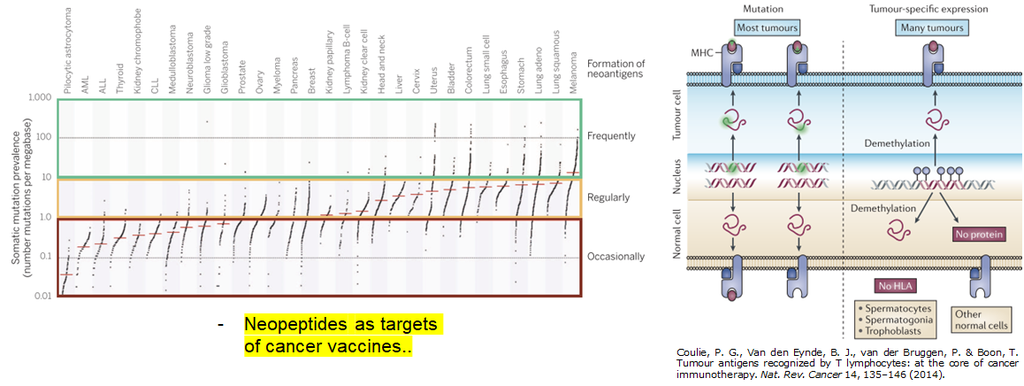

### **How T Cells see the cancer cells?**

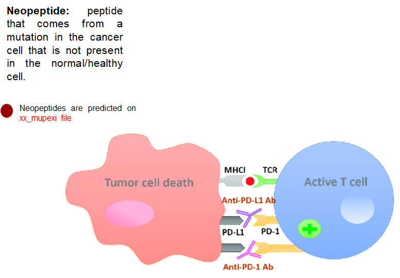

#### **NeoPepVac: a personalized therapeutic neopeptide-based vaccine**

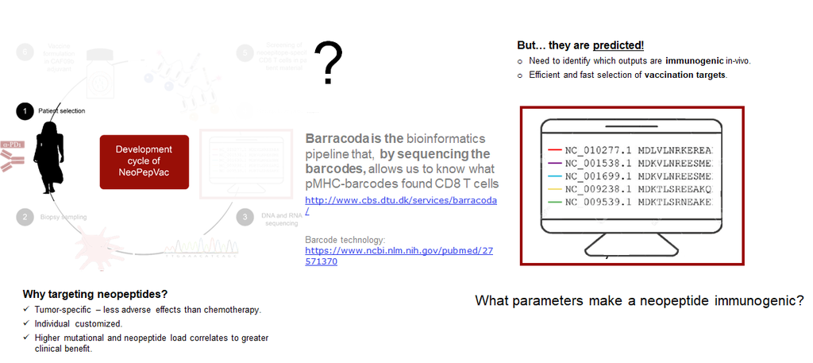

#### **Everything starts with a bioinformatician predicting neoepitopes: Mupexi**

- NGS pipeline: neoepitope prediction includes 24 scripts

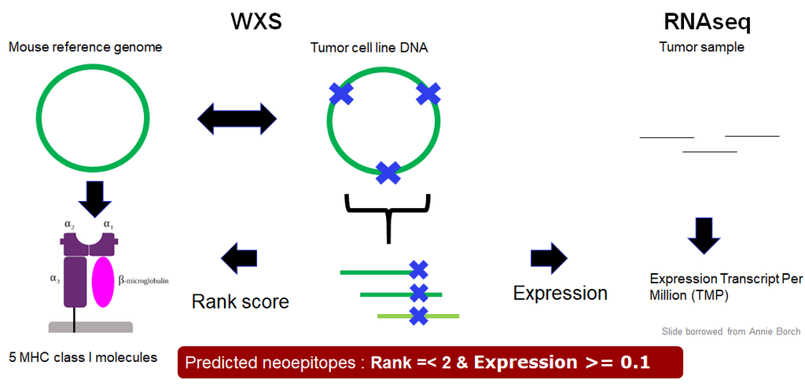

### **Experimental side**

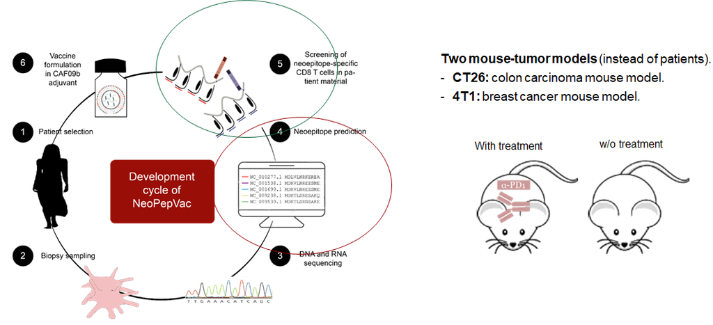

## Our Data

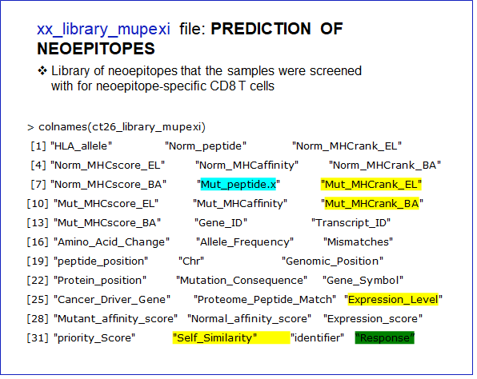

## Our Data

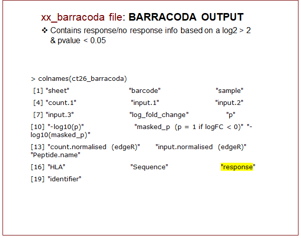

## Objective

#### What characteristics make neoepitopes elicit tumor-specific CD8 T cell responses?

- Combine xx_library_mupexi file with xx_barracoda file.
- Plot different characteristics of the responses vs no-responses neoepitopes.
- Store data wrangling and plotting functions into an R package.
- Develop a simple Shinny app to visualize the plots.
- Train an ANN to predict responses from the response/no response data

## Objective

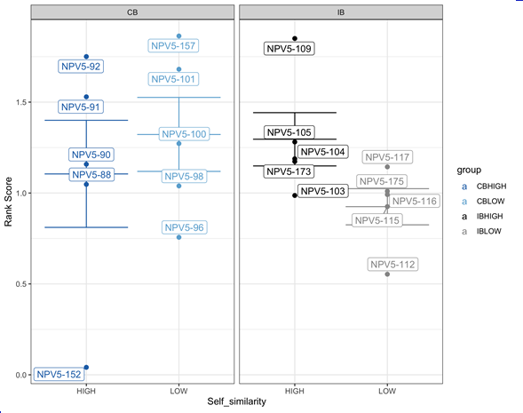

## Project Roadmap

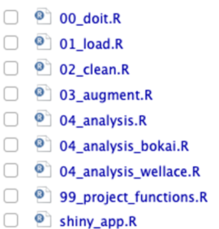

## Project Roadmap

[figure not shown]

## 00_doit

**Raw files**

```
# Run all scripts
# ------------------------------------------------------------------------------
source(file = "R/01_load.R")
source(file = "R/02_clean.R")
source(file = "R/03_augment.R")
source(file = "R/04_analysis.R")
```

## Getting Started

- Create a new R Markdown file in RStudio by going to  
  File > New File > R Markdown…
- Click the “presentation” tab
- Enter a title, author, and select what kind of slideshow you ultimately want (this can all be changed later)

## Getting Started

The beginning of an R Markdown file looks like this:  
`---`  
`title: "Air Quality"`  
`author: "JHU"`  
`date: "May 17, 2016"`  
`output: html_document`  
`---`  
The new document you’ve created will contain example text and code below this – delete it for a fresh start.

## Making Your First Slide

- Title your first slide using two # signs:  
  `## Insert Title Here`
- To make a slide without a title, use three asterisks:  
  `***`
- You can add subheadings with more # signs:  
  `### Subheading` or `#### Smaller Subheading`
- To add a new slide, just add another Title:  
  `## New Slide Title`

## Adding Text

- Add bullet points to a slide using a hyphen followed by a space:  
  `- bullet point`
- Add sub-points using four spaces and a plus sign:  
  `+ sub-point`
- Add an ordered list by typing the number/letter:  
  `1. first point`  
  `a) sub-sub-point`
- Add bullet points that appear one by one (on click) with:  
  `>- iterated bullet point`

## Formatting Text

| Text | Code in R Markdown |
| --- | --- |
| plain text | `plain text` |
| *italics* | `*italics*` |
| **bold** | `**bold**` |
| [link](http://www.jhsph.edu) | `[link](http://www.jhsph.edu)` |
| `verbatim code` | code here |

## Embedding R Code

This is a chunk of R code in R Markdown:  
```{r}  
`head(airquality)`  
```  
The code gets run, and both the input and output are displayed.

```
##   Ozone Solar.R Wind Temp Month Day
## 1    41     190  7.4   67     5   1
## 2    36     118  8.0   72     5   2
## 3    12     149 12.6   74     5   3
## 4    18     313 11.5   62     5   4
## 5    NA      NA 14.3   56     5   5
## 6    28      NA 14.9   66     5   6
```

## Embedding R Code

To hide the input code, use `echo=FALSE`.  
```{r, echo=FALSE}  
`head(airquality)`  
```

```
##   Ozone Solar.R Wind Temp Month Day
## 1    41     190  7.4   67     5   1
## 2    36     118  8.0   72     5   2
## 3    12     149 12.6   74     5   3
## 4    18     313 11.5   62     5   4
## 5    NA      NA 14.3   56     5   5
## 6    28      NA 14.9   66     5   6
```

This can be useful for showing plots.

## Embedding R Code

To show the input code only, use `eval=FALSE`.  
```{r, eval=FALSE}  
`head(airquality)`  
```

## Embedding R Code

To run the code without showing input or output, use `include=FALSE`.  
```{r, include=FALSE}  
`library(ggplot2)`  
```

## Generating Slideshows

- Click the **Knit** button at the top of the R Markdown document to generate your new document.
  - You may be asked to install required packages if you don’t already have them installed – hit “Yes” and RStudio will install them for you
- You can change the type of document generated by changing the `output` line in the header, or by selecting an output from the **Knit** button’s pull-down menu.

## Generating Slideshows

- HTML: two options with different looks
  - `output: ioslides_presentation`
  - `output: slidy_presentation`
- PDF: `output: beamer_presentation`
- Note: You can specify multiple outputs at the beginning of the R Markdown file if you will need to generate multiple filetypes.

## PDFs and LaTeX

- To **knit** a PDF slideshow, you will need to install **LaTeX** on your computer
- LaTeX is a typesetting system that is needed to convert R Markdown into formatted text for PDFs

### Downloading and Installing LaTeX

- *LaTeX* is free
- LaTeX takes up a lot of space (almost ~2.6 GB download and takes up ~5 GB when installed)
- Visit https://www.tug.org/begin.html to download LaTeX for your operating system
- Depending on your internet connection, it may take a while to download due to its size

## Conclusion

For more information about R Markdown visit http://rmarkdown.rstudio.com/